# Air Quality in Marginalized Communities

Will Munson

2023-06-24

## R Markdown

```r
library(tidyverse)
```

To start off, let’s load in our dataset for air quality.

```r
air_quality <- read.csv("C:/Users/wmuns/Downloads/Air_Quality.csv")
PM2.5 <- air_quality[air_quality$Name == "Fine Particulate Matter (PM2.5)",]
PM2.5_Borough <- PM2.5[PM2.5$Geo.Type.Name == "Borough",]
PM2.5_CD <- PM2.5[PM2.5$Geo.Type.Name == "CD",]
summary(PM2.5_CD)
```

```
##    Unique.ID       Indicator.ID     Name             Measure
##  Min.   :168394   Min.   :365   Length:2124        Length:2124
##  1st Qu.:169515   1st Qu.:365   Class :character   Class :character
##  Median :274175   Median :365   Mode  :character   Mode  :character
##  Mean   :356658   Mean   :365
##  3rd Qu.:562305   3rd Qu.:365
##  Max.   :669984   Max.   :365
##  Measure.Info       Geo.Type.Name       Geo.Join.ID    Geo.Place.Name
##  Length:2124        Length:2124        Min.   :101.0   Length:2124
##  Class :character   Class :character   1st Qu.:203.0   Class :character
##  Mode  :character   Mode  :character   Median :306.0   Mode  :character
##                                        Mean   :280.3
##                                        3rd Qu.:403.0
##                                        Max.   :503.0
##  Time.Period         Start_Date          Data.Value     Message
##  Length:2124        Length:2124        Min.   : 5.320   Mode:logical
##  Class :character   Class :character   1st Qu.: 8.040   NA's:2124
##  Mode  :character   Mode  :character   Median : 9.320
##                                        Mean   : 9.563
##                                        3rd Qu.:10.830
##                                        Max.   :18.840
```

Let’s take some yearly averages for the PM2.5. However, there appears to be something wrong with the $Start_Date$ variable. Let’s try converting this to a date.

```r
library(lubridate)
```

Now let’s fix the $Start_Date$ column:

```r
PM2.5_Borough$Start_Date <- mdy(PM2.5_Borough$Start_Date)
PM2.5_CD$Start_Date <- mdy(PM2.5_CD$Start_Date)
```

Alright, that worked! Now let’s set up a graph that shows exactly how things have changed overtime in each borough.

```r
PM2.5_Borough <- PM2.5_Borough %>%
  group_by(Start_Date, Geo.Place.Name) %>%
  #group_by(Geo.Join.ID) %>%
  summarise(mean = mean(Data.Value))
summary(PM2.5_Borough)
```

```
##    Start_Date         Geo.Place.Name          mean
##  Min.   :2008-12-01   Length:150         Min.   : 5.540
##  1st Qu.:2012-06-01   Class :character   1st Qu.: 7.728
##  Median :2015-08-31   Mode  :character   Median : 8.870
##  Mean   :2015-03-26                      Mean   : 9.103
##  3rd Qu.:2018-01-01                      3rd Qu.:10.428
##  Max.   :2020-06-01                      Max.   :13.985
```

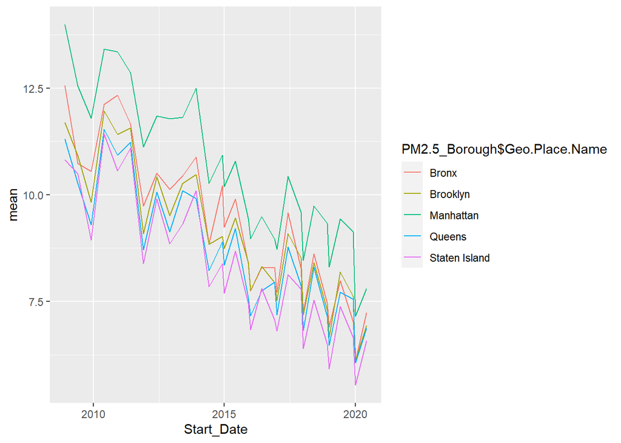

```r
i <- ggplot(PM2.5_Borough, aes(Start_Date, mean, group = Geo.Place.Name))
i + geom_line(aes(col = PM2.5_Borough$Geo.Place.Name))
```

Now let’s get the averages for PM2.5 each year.

```r
PM2.5_CD$year <- floor_date(PM2.5_CD$Start_Date, "year")

PM2.5_CD <- PM2.5_CD %>%
  group_by(year, Geo.Join.ID) %>%
  #group_by(Geo.Join.ID) %>%
  summarise(mean = mean(Data.Value), median = median(Data.Value), range = max(Data.Value)-min(Data.Value))
```

Now let’s load in some demographic data. We should also filter this so that we don’t have any blank columns. Now, this dataset appears to be super loaded, so this means we’re going to have to do a little extra cleaning because of it. On top of that, it seems like there were a lot of columns that were incorrectly labeled as character columns, meaning I ended up having to remove dozens of commas, dollar signs and percentage signs before changing them to numeric values using the *gsub* function.

```r
Demographics <- read.csv("C:/Users/wmuns/OneDrive/Documents/New York Demographic Data.csv", na.strings = c("","NA"))
District_Demographics <- Demographics[Demographics$region_type == "Community District",]
#District_Demographics$year <- ymd(District_Demographics$year, truncated = 2L)
#District_Demographics <- District_Demographics[District_Demographics$year > '2007-01-01' & District_Demographics$year < '2021-01-01',]
District_Demographics_Fix <- District_Demographics %>%
  filter(!is.na(region_name)) %>%
  filter(!is.na(region_display)) %>%
  distinct() %>%
  select_if(~!(all(is.na(.)) | all(. == "")))

District_Demographics_Fix$year <- ymd(District_Demographics_Fix$year, truncated = 2L)
District_Demographics_Fix <- District_Demographics_Fix[District_Demographics_Fix$year > '2007-01-01' & District_Demographics_Fix$year < '2021-01-01',]
District_Demographics_Fix <- head(District_Demographics_Fix, -42)
District_Demographics_Fix$hpi_ot <- as.numeric(gsub(",", "", District_Demographics_Fix$hpi_ot))
District_Demographics_Fix$hpi_1f <- as.numeric(gsub(",", "", District_Demographics_Fix$hpi_1f))
District_Demographics_Fix$hpi_4f <- as.numeric(gsub(",", "", District_Demographics_Fix$hpi_4f))
District_Demographics_Fix$lp_all <- as.numeric(gsub(",", "", District_Demographics_Fix$lp_all))
District_Demographics_Fix$lp_fam14condo_initial <- as.numeric(gsub(",", "", District_Demographics_Fix$lp_fam14condo_initial))
District_Demographics_Fix$lp_fam14condo_repeat <- as.numeric(gsub(",", "", District_Demographics_Fix$lp_fam14condo_repeat))
#District_Demographics_Fix <- District_Demographics_Fix %>%
 # mutate_if(is.character, as.numeric)
District_Demographics_Fix$med_r_1f <- as.numeric(gsub("[\\$,]", "", District_Demographics_Fix$med_r_1f))
District_Demographics_Fix$med_r_4f <- as.numeric(gsub("[\\$,]", "", District_Demographics_Fix$med_r_4f))
District_Demographics_Fix$med_r_cn <- as.numeric(gsub("[\\$,]", "", District_Demographics_Fix$med_r_cn))
District_Demographics_Fix$med_r_ot <- as.numeric(gsub("[\\$,]", "", District_Demographics_Fix$med_r_ot))
District_Demographics_Fix$nb_permit_res_units <- as.numeric(gsub(",", "", District_Demographics_Fix$nb_permit_res_units))
District_Demographics_Fix$pct_prof_ela <- as.numeric(gsub("%$", "", District_Demographics_Fix$pct_prof_ela))
District_Demographics_Fix$pct_prof_math <- as.numeric(gsub("%$", "", District_Demographics_Fix$pct_prof_math))
District_Demographics_Fix$pfn_fam14condo <- as.numeric(gsub(",", "", District_Demographics_Fix$pfn_fam14condo))
District_Demographics_Fix <- District_Demographics_Fix %>%
  select_if(~!(all(is.na(.))))
District_Demographics_Fix$priv_evic_amt_sought_med_adj <- as.numeric(gsub("[\\$,]", "", District_Demographics_Fix$priv_evic_amt_sought_med_adj))
District_Demographics_Fix$priv_evic_filings <- as.numeric(gsub(",", "", District_Demographics_Fix$priv_evic_filings))
District_Demographics_Fix$prox_park_pct <- as.numeric(gsub("%$", "", District_Demographics_Fix$prox_park_pct))
District_Demographics_Fix$prox_subway_pct <- as.numeric(gsub("%$", "", District_Demographics_Fix$prox_subway_pct))
District_Demographics_Fix$rent_change <- as.numeric(gsub("%$", "", District_Demographics_Fix$rent_change))
District_Demographics_Fix$reo <- as.numeric(gsub(",", "", District_Demographics_Fix$reo))
District_Demographics_Fix$units_cert <- as.numeric(gsub(",", "", District_Demographics_Fix$units_cert))
District_Demographics_Fix$volume_1f <- as.numeric(gsub(",", "", District_Demographics_Fix$volume_1f))
District_Demographics_Fix$volume_4f <- as.numeric(gsub(",", "", District_Demographics_Fix$volume_4f))
District_Demographics_Fix$volume_al <- as.numeric(gsub(",", "", District_Demographics_Fix$volume_al))
District_Demographics_Fix$volume_cn <- as.numeric(gsub(",", "", District_Demographics_Fix$volume_cn))
District_Demographics_Fix$volume_ot <- as.numeric(gsub(",", "", District_Demographics_Fix$volume_ot))
summary(District_Demographics_Fix)
```

```
##    region_id   region_display     region_name        region_type
##  Min.   :101   Length:766         Length:766         Length:766
##  1st Qu.:203   Class :character   Class :character   Class :character
##  Median :306   Mode  :character   Mode  :character   Mode  :character
##  Mean   :280
##  3rd Qu.:403
##  Max.   :503
##
##       year             crime_all_rt    crime_prop_rt     crime_viol_rt
##  Min.   :2008-01-01   Min.   :  2.80   Min.   :  2.100   Min.   : 0.600
##  1st Qu.:2011-01-01   1st Qu.:  9.00   1st Qu.:  6.000   1st Qu.: 2.600
##  Median :2014-01-01   Median : 11.90   Median :  7.200   Median : 4.200
##  Mean   :2013-12-28   Mean   : 14.34   Mean   :  9.434   Mean   : 4.905
##  3rd Qu.:2017-01-01   3rd Qu.: 16.18   3rd Qu.:  9.200   3rd Qu.: 6.800
##  Max.   :2020-01-01   Max.   :149.20   Max.   :133.800   Max.   :15.400
##
##      hpi_1f           hpi_4f           hpi_al          hpi_cn
##  Min.   :   6.9   Min.   :  75.4   Min.   :112.8   Min.   : 16.8
##  1st Qu.: 174.6   1st Qu.: 176.5   1st Qu.:194.8   1st Qu.:183.8
##  Median : 214.3   Median : 221.3   Median :238.0   Median :239.5
##  Mean   : 244.1   Mean   : 256.3   Mean   :261.0   Mean   :242.4
##  3rd Qu.: 283.8   3rd Qu.: 290.5   3rd Qu.:302.8   3rd Qu.:298.5
##  Max.   :1059.2   Max.   :1757.7   Max.   :643.0   Max.   :623.9
##  NA's   :69       NA's   :33                       NA's   :49
##      hpi_ot           lp_all       lp_fam14condo_initial lp_fam14condo_rate
##  Min.   :  34.9   Min.   :   2.0   Min.   :   0.0        Min.   : 0.40
##  1st Qu.: 234.8   1st Qu.:  47.0   1st Qu.:  21.0        1st Qu.: 4.60
##  Median : 319.1   Median : 103.0   Median :  51.0        Median :10.30
##  Mean   : 378.7   Mean   : 212.8   Mean   : 117.9        Mean   :14.98
##  3rd Qu.: 470.8   3rd Qu.: 269.0   3rd Qu.: 145.0        3rd Qu.:21.70
##  Max.   :2967.6   Max.   :2136.0   Max.   :1697.0        Max.   :61.40
##  NA's   :50       NA's   :1        NA's   :1             NA's   :1
##  lp_fam14condo_repeat    med_r_1f           med_r_4f          med_r_cn
##  Min.   :  0.00       Min.   :  111570   Min.   : 105480   Min.   :  66590
##  1st Qu.: 16.00       1st Qu.:  464890   1st Qu.: 263558   1st Qu.: 349225
##  Median : 38.00       Median :  656380   Median : 356835   Median : 494500
##  Mean   : 83.81       Mean   : 1604937   Mean   : 606017   Mean   : 659449
##  3rd Qu.:105.00       3rd Qu.: 1047200   3rd Qu.: 533960   3rd Qu.: 734792
##  Max.   :739.00       Max.   :16093230   Max.   :7813580   Max.   :4182860
##  NA's   :1            NA's   :33         NA's   :20        NA's   :30
```

[output cut: 33 more lines]

```
##  Min.   :  1.10    Min.   :  5.8   Min.   : -28.0   Min.   :   0.0
##  1st Qu.: 19.00    1st Qu.: 90.8   1st Qu.:  80.0   1st Qu.:   8.0
##  Median : 37.40    Median :170.3   Median : 207.0   Median :  38.5
##  Mean   : 56.27    Mean   :243.3   Mean   : 340.6   Mean   : 136.3
##  3rd Qu.: 92.70    3rd Qu.:391.2   3rd Qu.: 413.0   3rd Qu.: 146.0
##  Max.   :219.80    Max.   :907.6   Max.   :2829.0   Max.   :1395.0
##
##    volume_4f       volume_al        volume_cn        volume_ot
##  Min.   :  0.0   Min.   :  22.0   Min.   :   0.0   Min.   :  0.00
##  1st Qu.: 30.0   1st Qu.: 229.8   1st Qu.:  25.0   1st Qu.:  8.00
##  Median :111.5   Median : 402.5   Median :  76.0   Median : 18.00
##  Mean   :135.4   Mean   : 478.8   Mean   : 182.9   Mean   : 24.14
##  3rd Qu.:212.8   3rd Qu.: 643.2   3rd Qu.: 207.8   3rd Qu.: 35.00
##  Max.   :725.0   Max.   :2007.0   Max.   :1664.0   Max.   :142.00
##
```

Alright, with that taken care of, we should try joining our datasets together. Since we have repeat ID’s involved, we can’t just assume we should join only ID’s together and assume we’re done. In that case, we need to join by both ID and year.

```r
Demo2.5 <- merge(PM2.5_CD, District_Demographics_Fix, by.x = c("Geo.Join.ID", "year"), by.y = c("region_id", "year"))
summary(Demo2.5)
```

```
##   Geo.Join.ID       year                 mean            median
##  Min.   :101   Min.   :2008-01-01   Min.   : 5.800   Min.   : 5.800
##  1st Qu.:203   1st Qu.:2011-01-01   1st Qu.: 7.973   1st Qu.: 7.956
##  Median :306   Median :2014-01-01   Median : 9.470   Median : 9.363
##  Mean   :280   Mean   :2013-12-28   Mean   : 9.550   Mean   : 9.502
##  3rd Qu.:403   3rd Qu.:2017-01-01   3rd Qu.:10.903   3rd Qu.:10.795
##  Max.   :503   Max.   :2020-01-01   Max.   :17.465   Max.   :17.465
##
##      range       region_display     region_name        region_type
##  Min.   :0.000   Length:766         Length:766         Length:766
##  1st Qu.:1.090   Class :character   Class :character   Class :character
##  Median :1.620   Mode  :character   Mode  :character   Mode  :character
##  Mean   :1.676
##  3rd Qu.:2.330
##  Max.   :3.870
##
##   crime_all_rt    crime_prop_rt     crime_viol_rt        hpi_1f
##  Min.   :  2.80   Min.   :  2.100   Min.   : 0.600   Min.   :   6.9
##  1st Qu.:  9.00   1st Qu.:  6.000   1st Qu.: 2.600   1st Qu.: 174.6
##  Median : 11.90   Median :  7.200   Median : 4.200   Median : 214.3
##  Mean   : 14.34   Mean   :  9.434   Mean   : 4.905   Mean   : 244.1
##  3rd Qu.: 16.18   3rd Qu.:  9.200   3rd Qu.: 6.800   3rd Qu.: 283.8
##  Max.   :149.20   Max.   :133.800   Max.   :15.400   Max.   :1059.2
##                                                      NA's   :69
##      hpi_4f           hpi_al          hpi_cn          hpi_ot
##  Min.   :  75.4   Min.   :112.8   Min.   : 16.8   Min.   :  34.9
##  1st Qu.: 176.5   1st Qu.:194.8   1st Qu.:183.8   1st Qu.: 234.8
##  Median : 221.3   Median :238.0   Median :239.5   Median : 319.1
##  Mean   : 256.3   Mean   :261.0   Mean   :242.4   Mean   : 378.7
##  3rd Qu.: 290.5   3rd Qu.:302.8   3rd Qu.:298.5   3rd Qu.: 470.8
##  Max.   :1757.7   Max.   :643.0   Max.   :623.9   Max.   :2967.6
##  NA's   :33                       NA's   :49      NA's   :50
##      lp_all       lp_fam14condo_initial lp_fam14condo_rate lp_fam14condo_repeat
##  Min.   :   2.0   Min.   :   0.0        Min.   : 0.40      Min.   :  0.00
##  1st Qu.:  47.0   1st Qu.:  21.0        1st Qu.: 4.60      1st Qu.: 16.00
##  Median : 103.0   Median :  51.0        Median :10.30      Median : 38.00
##  Mean   : 212.8   Mean   : 117.9        Mean   :14.98      Mean   : 83.81
##  3rd Qu.: 269.0   3rd Qu.: 145.0        3rd Qu.:21.70      3rd Qu.:105.00
##  Max.   :2136.0   Max.   :1697.0        Max.   :61.40      Max.   :739.00
##  NA's   :1        NA's   :1             NA's   :1          NA's   :1
```

[output cut: 41 more lines]

```
##  Min.   : -28.0   Min.   :   0.0   Min.   :  0.0   Min.   :  22.0
##  1st Qu.:  80.0   1st Qu.:   8.0   1st Qu.: 30.0   1st Qu.: 229.8
##  Median : 207.0   Median :  38.5   Median :111.5   Median : 402.5
##  Mean   : 340.6   Mean   : 136.3   Mean   :135.4   Mean   : 478.8
##  3rd Qu.: 413.0   3rd Qu.: 146.0   3rd Qu.:212.8   3rd Qu.: 643.2
##  Max.   :2829.0   Max.   :1395.0   Max.   :725.0   Max.   :2007.0
##
##    volume_cn        volume_ot
##  Min.   :   0.0   Min.   :  0.00
##  1st Qu.:  25.0   1st Qu.:  8.00
##  Median :  76.0   Median : 18.00
##  Mean   : 182.9   Mean   : 24.14
##  3rd Qu.: 207.8   3rd Qu.: 35.00
##  Max.   :1664.0   Max.   :142.00
##
```

Alright, now that we have that taken care of, let’s take a look at a linear model that might work for this dataset.

EDIT: Maybe before we get to that, we should do some *ggplot* functions real quick.

```r
library(ggplot2)
```

Just to make sure we understand how the data works before we start diving into creating linear models, we should probably take a look at each factor’s distribution.

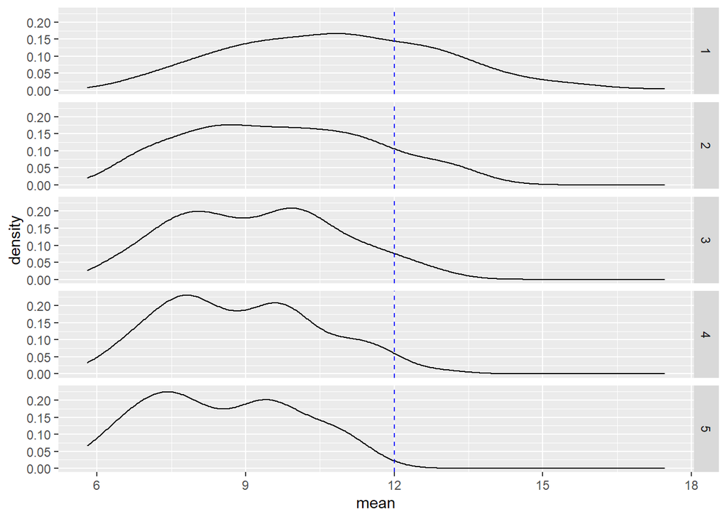

```r
c <- ggplot(Demo2.5, aes(mean))
c + geom_density() + facet_grid(rows = vars(factor(findInterval(Geo.Join.ID, c(100, 200, 300, 400, 500))))) + geom_vline(aes(xintercept = 12),lty=2, color = 'blue')
```

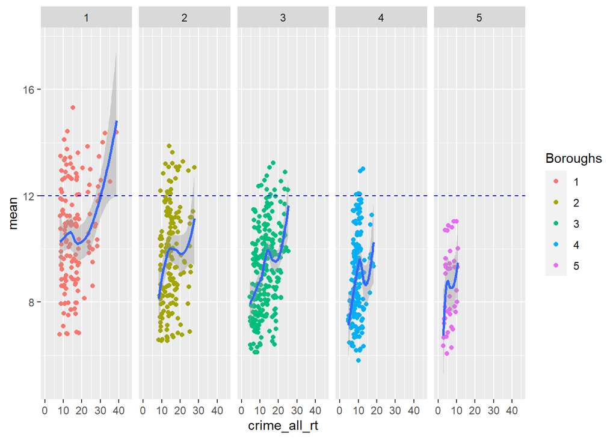

```r
e <- ggplot(Demo2.5, aes(crime_all_rt, mean)) + labs(color = "Boroughs")
#legend_title <- "Boroughs"
e + geom_point(aes(color = factor(findInterval(Geo.Join.ID, c(100, 200, 300, 400, 500))))) + facet_grid(cols = vars(factor(findInterval(Geo.Join.ID, c(100, 200, 300, 400, 500))))) + geom_smooth() + xlim(0,45) + geom_hline(aes(yintercept = 12),lty=2, color = 'blue')
```

What I did here is I basically lined up all the variables using the linear model function, or *lm()*, to get a better understanding of how each variable works with each other. Initially, I tried lining up all the variables into the whole model, but this did not turn out so well. Some of the data was missing, including proximity to parks and subways, or change in rent, so I had to exclude those points in order to get a better understanding of the rest of the model. Also, anything with a $Pr(>|t|) > 0.5$ is considered unfit for the model and was removed as a result.

```r
mod <- lm(mean ~ year + crime_all_rt + hpi_al + lp_all + med_r_4f + med_r_ot + nb_permit_res_units + pct_prof_ela + pfn_fam14condo + pfn_fam14condo_rate + priv_evic_filing_rt + priv_evic_filings + total_viol_rate + volume_1f + volume_4f + volume_al + population_density, data = Demo2.5)
summary(mod)
```

```
##
## Call:
## lm(formula = mean ~ year + crime_all_rt + hpi_al + lp_all + med_r_4f +
##     med_r_ot + nb_permit_res_units + pct_prof_ela + pfn_fam14condo +
##     pfn_fam14condo_rate + priv_evic_filing_rt + priv_evic_filings +
##     total_viol_rate + volume_1f + volume_4f + volume_al + population_density,
##     data = Demo2.5)
##
## Residuals:
##      Min       1Q   Median       3Q      Max
## -1.55079 -0.36823 -0.02885  0.31585  2.26314
##
## Coefficients:
##                       Estimate Std. Error t value Pr(>|t|)
## (Intercept)          2.803e+01  1.006e+00  27.853  < 2e-16 ***
## year                -1.197e-03  7.112e-05 -16.835  < 2e-16 ***
## crime_all_rt         5.155e-02  5.672e-03   9.088  < 2e-16 ***
## hpi_al              -6.496e-04  5.166e-04  -1.258 0.209330
## lp_all              -1.969e-03  3.574e-04  -5.509 6.71e-08 ***
## med_r_4f            -1.383e-07  5.920e-08  -2.336 0.020017 *
## med_r_ot             4.290e-07  3.965e-07   1.082 0.280021
## nb_permit_res_units  5.870e-05  4.567e-05   1.285 0.199516
## pct_prof_ela         6.160e-03  4.692e-03   1.313 0.190037
## pfn_fam14condo       4.032e-04  1.092e-04   3.692 0.000255 ***
## pfn_fam14condo_rate  9.074e-03  1.730e-03   5.245 2.62e-07 ***
## priv_evic_filing_rt -4.692e-03  1.350e-03  -3.476 0.000568 ***
## priv_evic_filings    4.363e-05  3.119e-05   1.399 0.162666
## total_viol_rate     -4.489e-04  3.550e-04  -1.264 0.206868
## volume_1f           -2.313e-03  3.147e-04  -7.350 1.24e-12 ***
## volume_4f           -3.252e-03  4.530e-04  -7.180 3.74e-12 ***
## volume_al            1.402e-03  2.069e-04   6.776 4.77e-11 ***
## population_density   3.874e-03  2.151e-03   1.801 0.072455 .
## ---
## Signif. codes:  0 '***' 0.001 '**' 0.01 '*' 0.05 '.' 0.1 ' ' 1
##
## Residual standard error: 0.5515 on 377 degrees of freedom
##   (371 observations deleted due to missingness)
## Multiple R-squared:  0.8308, Adjusted R-squared:  0.8232
## F-statistic: 108.9 on 17 and 377 DF,  p-value: < 2.2e-16
```

So, the issue we’re running into is the first things that we would usually go for whenever studying marginalized communities do not show any data for the community districts listed in the demographics data. This means we’d have to select other indicators in order to see if there’s any impact as a result of high PM2.5 levels. In this case, we’re looking at both violent and property crime, median rent, and academic performance among elementary school students.

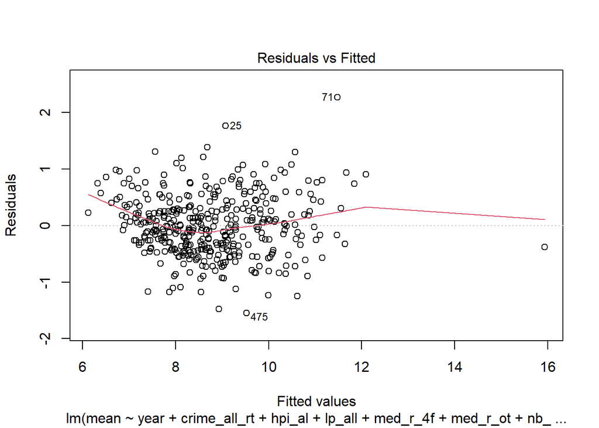

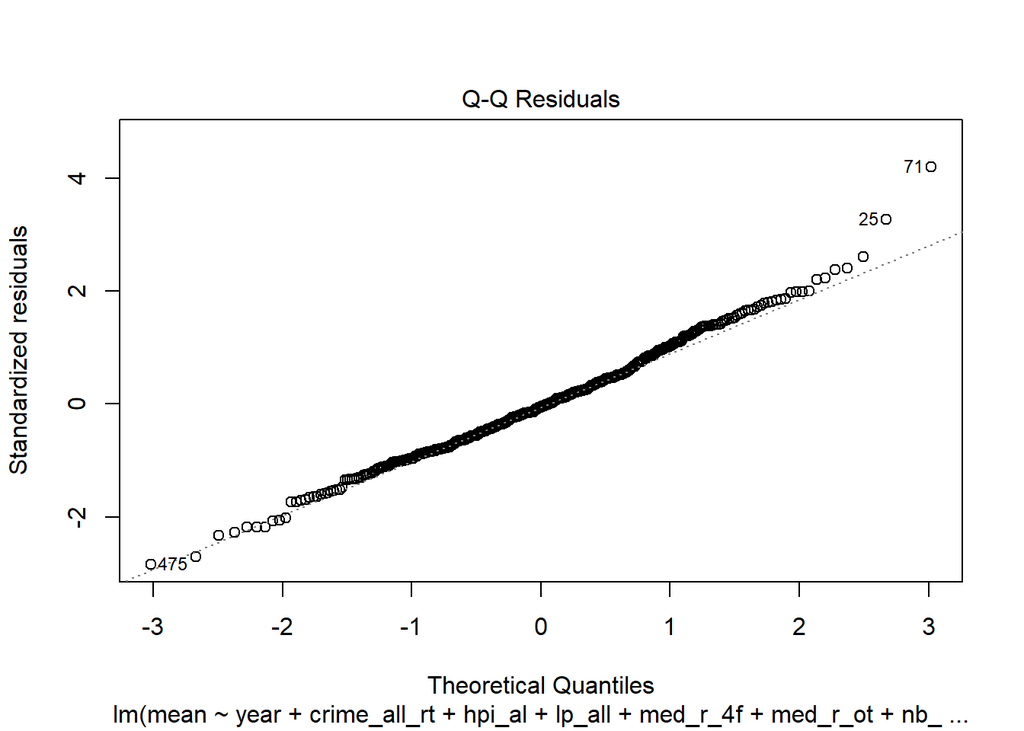

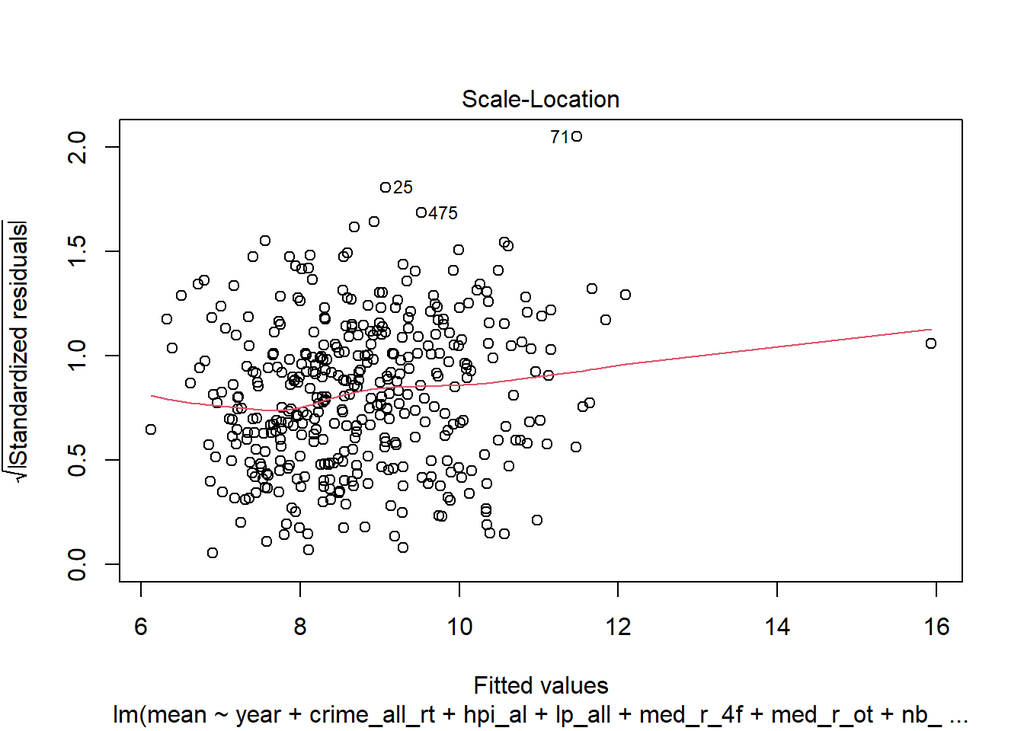

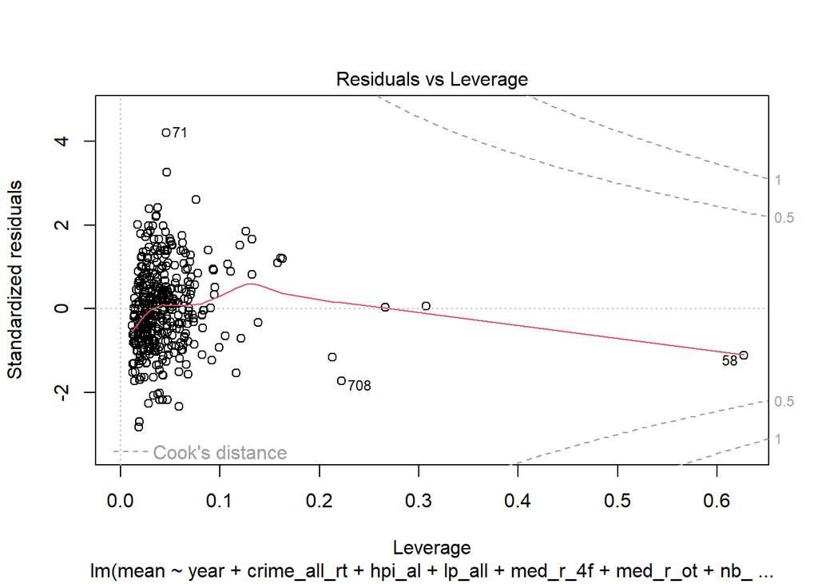

```r
plot(mod)
```

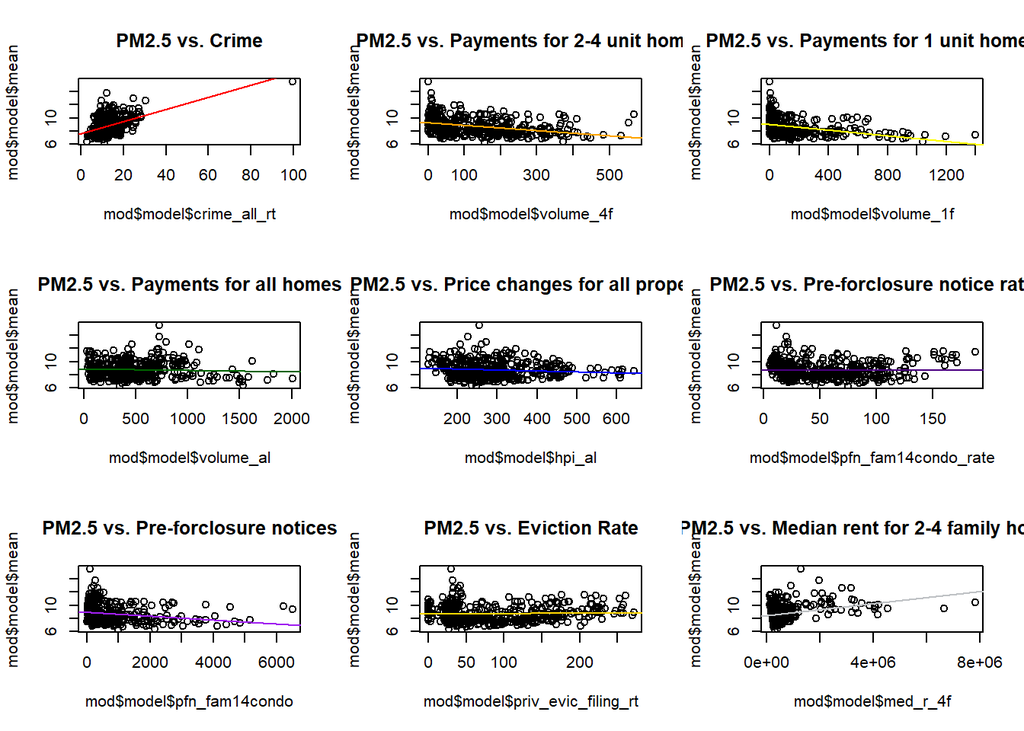

```r
par(mfrow=c(3,3))
plot(mod$model$crime_all_rt, mod$model$mean, main = "PM2.5 vs. Crime")
abline(lm(mod$model$mean ~ mod$model$crime_all_rt), col = 'red')
plot(mod$model$volume_4f, mod$model$mean, main = "PM2.5 vs. Payments for 2-4 unit homes")
abline(lm(mod$model$mean ~ mod$model$volume_4f), col = 'orange')
plot(mod$model$volume_1f, mod$model$mean, main = "PM2.5 vs. Payments for 1 unit homes")
abline(lm(mod$model$mean ~ mod$model$volume_1f), col = 'yellow')
plot(mod$model$volume_al, mod$model$mean, main = "PM2.5 vs. Payments for all homes")
abline(lm(mod$model$mean ~ mod$model$volume_al), col = 'darkgreen')
plot(mod$model$hpi_al, mod$model$mean, main = "PM2.5 vs. Price changes for all property")
abline(lm(mod$model$mean ~ mod$model$hpi_al), col = 'blue')
plot(mod$model$pfn_fam14condo_rate, mod$model$mean, main = "PM2.5 vs. Pre-forclosure notice rate")
abline(lm(mod$model$mean ~ mod$model$pfn_fam14condo_rate), col = '#4B0082')
plot(mod$model$pfn_fam14condo, mod$model$mean, main = "PM2.5 vs. Pre-forclosure notices")
abline(lm(mod$model$mean ~ mod$model$pfn_fam14condo), col = 'purple')
plot(mod$model$priv_evic_filing_rt, mod$model$mean, main = "PM2.5 vs. Eviction Rate")
abline(lm(mod$model$mean ~ mod$model$priv_evic_filing_rt), col = 'gold')
plot(mod$model$med_r_4f, mod$model$mean, main = "PM2.5 vs. Median rent for 2-4 family homes")
abline(lm(mod$model$mean ~ mod$model$med_r_4f), col = '#BFC2C5')
```

Now, let’s observe their coefficients individually.

```r
mod_crime <- lm(mod$model$mean ~ mod$model$crime_all_rt)
mod_vol_4f <- lm(mod$model$mean ~ mod$model$volume_4f)
mod_vol_1f <- lm(mod$model$mean ~ mod$model$volume_1f)
mod_vol_al <- lm(mod$model$mean ~ mod$model$volume_al)
mod_hpi_al <- lm(mod$model$mean ~ mod$model$hpi_al)
mod_pfn_rate <- lm(mod$model$mean ~ mod$model$pfn_fam14condo_rate)
mod_pfn <- lm(mod$model$mean ~ mod$model$pfn_fam14condo)
mod_evic_rt <- lm(mod$model$mean ~ mod$model$priv_evic_filing_rt)
mod_med_4f <- lm(mod$model$mean ~ mod$model$med_r_4f)

mod_crime
```

```
##
## Call:
## lm(formula = mod$model$mean ~ mod$model$crime_all_rt)
##
## Coefficients:
##            (Intercept)  mod$model$crime_all_rt
##                 7.5809                  0.0927
```

```r
mod_vol_4f
```

```
##
## Call:
## lm(formula = mod$model$mean ~ mod$model$volume_4f)
##
## Coefficients:
##         (Intercept)  mod$model$volume_4f
##            9.331179            -0.004079
```

```r
mod_vol_1f
```

```
##
## Call:
## lm(formula = mod$model$mean ~ mod$model$volume_1f)
##
## Coefficients:
##         (Intercept)  mod$model$volume_1f
##            9.057170            -0.002174
```

```r
mod_vol_al
```

```
##
## Call:
## lm(formula = mod$model$mean ~ mod$model$volume_al)
##
## Coefficients:
##         (Intercept)  mod$model$volume_al
##           8.8707242           -0.0002294
```

```r
mod_hpi_al
```

```
##
## Call:
## lm(formula = mod$model$mean ~ mod$model$hpi_al)
##
## Coefficients:
##      (Intercept)  mod$model$hpi_al
##         9.155564         -0.001348
```

```r
mod_pfn_rate
```

```
##
## Call:
## lm(formula = mod$model$mean ~ mod$model$pfn_fam14condo_rate)
##
## Coefficients:
##                   (Intercept)  mod$model$pfn_fam14condo_rate
##                      8.807208                      -0.000831
```

```r
mod_pfn
```

```
##
## Call:
## lm(formula = mod$model$mean ~ mod$model$pfn_fam14condo)
##
## Coefficients:
##              (Intercept)  mod$model$pfn_fam14condo
##                 8.999256                 -0.000305
```

```r
mod_evic_rt
```

```
##
## Call:
## lm(formula = mod$model$mean ~ mod$model$priv_evic_filing_rt)
##
## Coefficients:
##                   (Intercept)  mod$model$priv_evic_filing_rt
##                      8.712244                       0.000539
```

```r
mod_med_4f
```

```
##
## Call:
## lm(formula = mod$model$mean ~ mod$model$med_r_4f)
##
## Coefficients:
##        (Intercept)  mod$model$med_r_4f
##          8.455e+00           4.483e-07
```

Now, we need to observe their R-squared.

```r
summary(mod_crime)$r.squared
```

```
## [1] 0.2311599
```

```r
summary(mod_vol_4f)$r.squared
```

```
## [1] 0.1382664
```

```r
summary(mod_vol_1f)$r.squared
```

```
## [1] 0.1329233
```

```r
summary(mod_vol_al)$r.squared
```

```
## [1] 0.003629368
```

```r
summary(mod_hpi_al)$r.squared
```

```
## [1] 0.01043826
```

```r
summary(mod_pfn_rate)$r.squared
```

```
## [1] 0.0005988915
```

```r
summary(mod_pfn)$r.squared
```

```
## [1] 0.05292666
```

```r
summary(mod_evic_rt)$r.squared
```

```
## [1] 0.0007887765
```

```r
summary(mod_med_4f)$r.squared
```

```
## [1] 0.09282217
```

So, clearly, there is no strong correlation between any of these variables here. Let’s look at the residual graphs now.

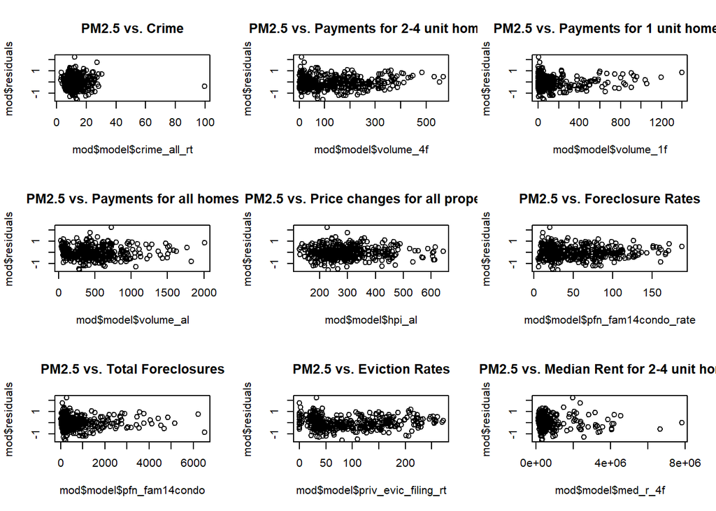

```r
par(mfrow=c(3,3))
plot(mod$model$crime_all_rt, mod$residuals, main = "PM2.5 vs. Crime")
plot(mod$model$volume_4f, mod$residuals, main = "PM2.5 vs. Payments for 2-4 unit homes")
plot(mod$model$volume_1f, mod$residuals, main = "PM2.5 vs. Payments for 1 unit homes")
plot(mod$model$volume_al, mod$residuals, main = "PM2.5 vs. Payments for all homes")
plot(mod$model$hpi_al, mod$residuals, main = "PM2.5 vs. Price changes for all property")
plot(mod$model$pfn_fam14condo_rate, mod$residuals, main = "PM2.5 vs. Foreclosure Rates")
plot(mod$model$pfn_fam14condo, mod$residuals, main = "PM2.5 vs. Total Foreclosures")
plot(mod$model$priv_evic_filing_rt, mod$residuals, main = "PM2.5 vs. Eviction Rates")
plot(mod$model$med_r_4f, mod$residuals, main = "PM2.5 vs. Median Rent for 2-4 unit homes")
```

So there appears to be one point in each of these graphs that’s standing out amongst the crowd. The distribution doesn’t appear to be too out of the ordinary, but it does appear to show a level of significance among each of these variables.

```r
mod_edu <- lm(Demo2.5$mean ~ (Demo2.5$pct_prof_math*Demo2.5$pct_prof_ela))
summary(mod_edu)
```

```
##
## Call:
## lm(formula = Demo2.5$mean ~ (Demo2.5$pct_prof_math * Demo2.5$pct_prof_ela))
##
## Residuals:
##     Min      1Q  Median      3Q     Max
## -3.2010 -0.6851 -0.1960  0.6176  5.9336
##
## Coefficients:
##                                              Estimate Std. Error t value
## (Intercept)                                11.4005598  0.3301071  34.536
## Demo2.5$pct_prof_math                       0.0099699  0.0107030   0.932
## Demo2.5$pct_prof_ela                       -0.1504317  0.0118783 -12.664
## Demo2.5$pct_prof_math:Demo2.5$pct_prof_ela  0.0014988  0.0001624   9.227
##                                            Pr(>|t|)
## (Intercept)                                  <2e-16 ***
## Demo2.5$pct_prof_math                         0.352
## Demo2.5$pct_prof_ela                         <2e-16 ***
## Demo2.5$pct_prof_math:Demo2.5$pct_prof_ela   <2e-16 ***
## ---
## Signif. codes:  0 '***' 0.001 '**' 0.01 '*' 0.05 '.' 0.1 ' ' 1
##
## Residual standard error: 1.172 on 409 degrees of freedom
##   (353 observations deleted due to missingness)
## Multiple R-squared:  0.2875, Adjusted R-squared:  0.2823
## F-statistic: 55.02 on 3 and 409 DF,  p-value: < 2.2e-16
```

I also checked for autocorrelation between these two variables. Looks like they’re pretty good.

[figure not shown]

```r
plot(mod$model$pct_prof_ela, mod$model$pct_prof_math)
```

Now, we should take a look at how influential each point appears to be. The more influential they are, the greater an effect they have on our data. To measure that, I used the Cooks Distance to get an idea of how unusual each point is.

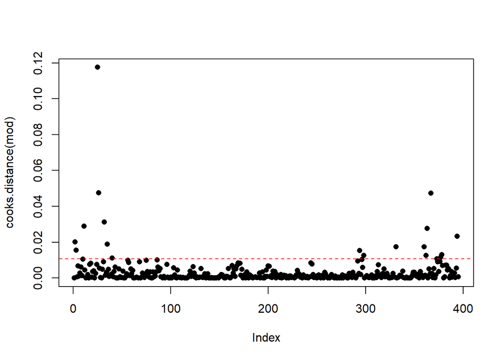

```r
N <- 395
k <- 17

plot(cooks.distance(mod), pch = 16)
cutoff = 4/ (N-k-1)
abline(h=cutoff,lty=2, col = 'red')
```

```r
cooks.distance(mod)[which.max(cooks.distance(mod))]
```

```
##        58
## 0.1175352
```

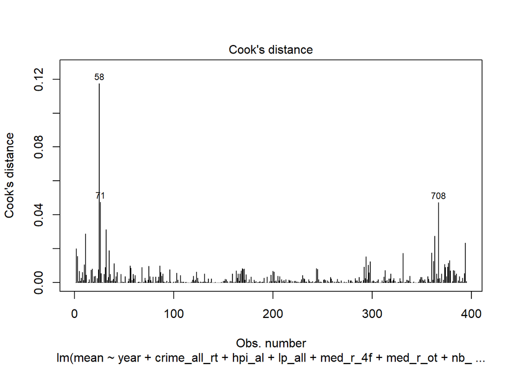

```r
plot(mod,which=4)
```

As we can see, quire a few of our data points appear to be above the cutoff line. Not such a great look for our data now, is it?

```r
library(broom)
augment(mod)
```

```
## # A tibble: 395 × 25
##    .rownames  mean year       crime_all_rt hpi_al lp_all med_r_4f med_r_ot
##    <chr>     <dbl> <date>            <dbl>  <dbl>  <dbl>    <dbl>    <dbl>
##  1 8         10.4  2015-01-01         18.5   276.     45  7813580   861630
##  2 9          9.47 2016-01-01         18.4   288.     34  6659270   638590
##  3 11         9.53 2018-01-01         16.6   280.     37  4539850   325570
##  4 12         9.38 2019-01-01         18     275.     22  2022850   965430
##  5 19        12.6  2013-01-01         30.4   260.     19  2845260   772290
##  6 20        10.9  2014-01-01         27.6   293.     20  3201260  1070600
##  7 21        10.3  2015-01-01         28.2   309.      9  3567430   990950
##  8 22         9.51 2016-01-01         25.8   313.      8  3359600   718900
##  9 23         9.99 2017-01-01         25.8   315.     17  3869870   798860
## 10 24        10.1  2018-01-01         28.2   311.     16  4203540   804710
## # ℹ 385 more rows
## # ℹ 17 more variables: nb_permit_res_units <dbl>, pct_prof_ela <dbl>,
## #   pfn_fam14condo <dbl>, pfn_fam14condo_rate <dbl>, priv_evic_filing_rt <dbl>,
## #   priv_evic_filings <dbl>, total_viol_rate <dbl>, volume_1f <dbl>,
## #   volume_4f <dbl>, volume_al <dbl>, population_density <dbl>, .fitted <dbl>,
## #   .resid <dbl>, .hat <dbl>, .sigma <dbl>, .cooksd <dbl>, .std.resid <dbl>
```

```r
cooksd <- cooks.distance(mod)
influential <- names(cooksd)[(cooksd > (cutoff))]
mod_screen <- mod$model[influential, ]
mod_screen
```

```
##          mean       year crime_all_rt hpi_al lp_all med_r_4f med_r_ot
## 9    9.470000 2016-01-01         18.4  287.8     34  6659270   638590
## 11   9.533333 2018-01-01         16.6  279.8     37  4539850   325570
## 25  10.836667 2019-01-01         27.1  298.8     10  2381880   710330
## 58  15.553333 2013-01-01         99.5  255.4     24  1280370   878860
## 71  13.743333 2013-01-01         11.9  226.0     36  1991680   455240
## 77  10.070000 2019-01-01         12.9  257.0    130  1506190   666230
## 86   9.375000 2015-01-01          8.8  297.8     32  2575550   669130
## 97  12.603333 2013-01-01          9.4  207.7     53  3186690   609000
## 567 10.087500 2015-01-01          9.7  301.7     59   392640   245680
## 571  8.863333 2019-01-01          8.7  361.3     39   518760   315250
## 634  8.060000 2017-01-01          7.1  291.3    151   535670   284740
## 695  9.800000 2013-01-01         16.8  137.0   1670   211550    98760
## 697  7.917500 2015-01-01         14.4  187.4   1397   269240   110500
## 698  7.750000 2016-01-01         13.2  199.5   1327   285790   238760
```

[output cut: 65 more lines]

```r
mod_clean <- mod$model %>% anti_join(mod_screen)
```

[output not shown]

```r
#mod_clean <- mod_clean[-25,]
mod_clean <- lm(mean ~ ., data = mod_clean)
summary(mod_clean)
```

```
##
## Call:
## lm(formula = mean ~ ., data = mod_clean)
##
## Residuals:
##      Min       1Q   Median       3Q      Max
## -1.59782 -0.35218 -0.01163  0.31042  1.23799
##
## Coefficients:
##                       Estimate Std. Error t value Pr(>|t|)
## (Intercept)          2.823e+01  9.452e-01  29.861  < 2e-16 ***
## year                -1.184e-03  6.677e-05 -17.731  < 2e-16 ***
## crime_all_rt         4.818e-02  8.343e-03   5.775 1.67e-08 ***
## hpi_al              -5.794e-04  4.984e-04  -1.163   0.2458
## lp_all              -2.750e-03  3.861e-04  -7.122 5.86e-12 ***
## med_r_4f            -8.900e-08  6.529e-08  -1.363   0.1737
## med_r_ot             4.713e-07  3.944e-07   1.195   0.2328
## nb_permit_res_units  1.434e-05  4.609e-05   0.311   0.7560
## pct_prof_ela        -2.651e-04  4.347e-03  -0.061   0.9514
## pfn_fam14condo       5.524e-04  1.135e-04   4.869 1.69e-06 ***
## pfn_fam14condo_rate  9.079e-03  1.634e-03   5.556 5.38e-08 ***
## priv_evic_filing_rt -5.386e-03  1.303e-03  -4.134 4.45e-05 ***
## priv_evic_filings    6.098e-05  2.904e-05   2.100   0.0364 *
## total_viol_rate     -2.703e-04  3.247e-04  -0.832   0.4057
## volume_1f           -2.739e-03  3.066e-04  -8.934  < 2e-16 ***
## volume_4f           -3.365e-03  4.239e-04  -7.939 2.65e-14 ***
## volume_al            1.649e-03  2.028e-04   8.132 7.02e-15 ***
## population_density  -1.028e-03  2.056e-03  -0.500   0.6174
## ---
## Signif. codes:  0 '***' 0.001 '**' 0.01 '*' 0.05 '.' 0.1 ' ' 1
##
## Residual standard error: 0.4955 on 358 degrees of freedom
## Multiple R-squared:  0.8442, Adjusted R-squared:  0.8368
## F-statistic: 114.1 on 17 and 358 DF,  p-value: < 2.2e-16
```

```r
mod_vol_4f_clean <- lm(mod_clean$model$mean ~ mod_clean$model$volume_4f)
mod_vol_1f_clean <- lm(mod_clean$model$mean ~ mod_clean$model$volume_1f)
mod_vol_al_clean <- lm(mod_clean$model$mean ~ mod_clean$model$volume_al)
#mod_vol_cn_clean <- lm(mod_clean$model$mean ~ mod_clean$model$volume_cn)
mod_vol_4f_clean
```

```
##
## Call:
## lm(formula = mod_clean$model$mean ~ mod_clean$model$volume_4f)
##
## Coefficients:
##               (Intercept)  mod_clean$model$volume_4f
##                  9.242491                  -0.003716
```

```r
mod_vol_1f_clean
```

```
##
## Call:
## lm(formula = mod_clean$model$mean ~ mod_clean$model$volume_1f)
##
## Coefficients:
##               (Intercept)  mod_clean$model$volume_1f
##                  9.017318                  -0.002252
```

```r
mod_vol_al_clean
```

```
##
## Call:
## lm(formula = mod_clean$model$mean ~ mod_clean$model$volume_al)
##
## Coefficients:
##               (Intercept)  mod_clean$model$volume_al
##                 8.8891714                 -0.0003597
```

```r
#mod_vol_cn_clean
```

```r
summary(mod_vol_4f_clean)$r.squared
```

```
## [1] 0.127649
```

```r
summary(mod_vol_1f_clean)$r.squared
```

```
## [1] 0.1472989
```

```r
summary(mod_vol_al_clean)$r.squared
```

```
## [1] 0.009287534
```

```r
#summary(mod_vol_cn_clean)$r.squared
```

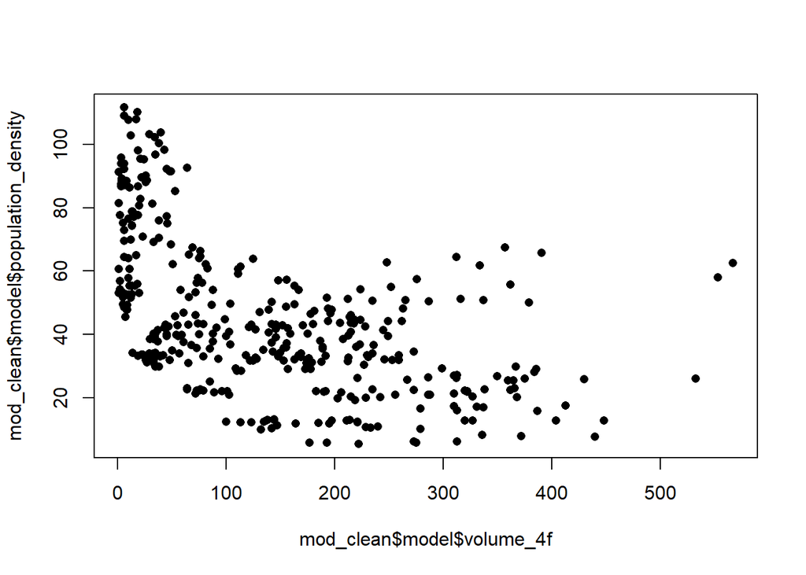

```r
plot(mod_clean$model$volume_4f, mod_clean$model$population_density, pch = 16)
```

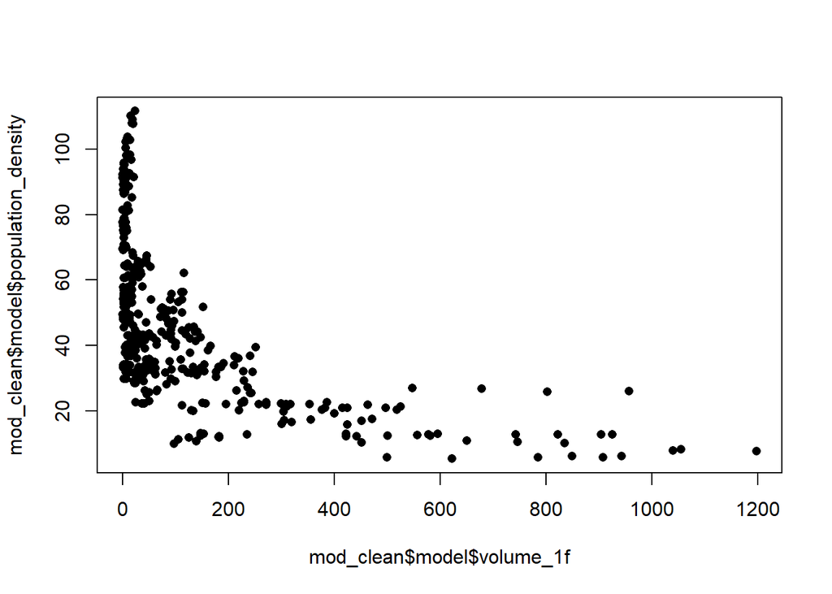

```r
plot(mod_clean$model$volume_1f, mod_clean$model$population_density, pch = 16)
```

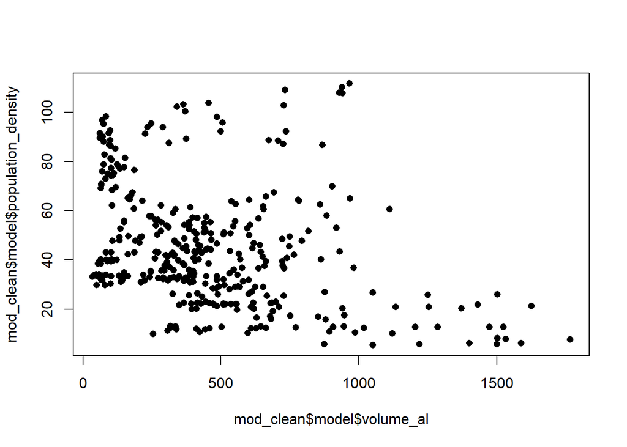

```r
plot(mod_clean$model$volume_al, mod_clean$model$population_density, pch = 16)
```

```r
#plot(mod_clean$model$volume_cn, mod_clean$model$population_density, pch = 16)
```

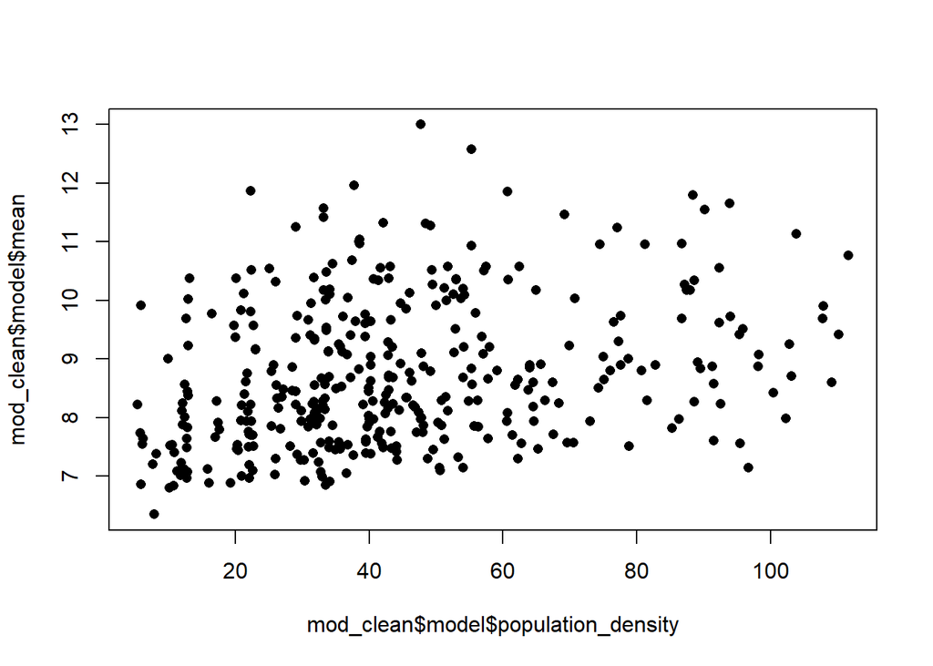

```r
plot(mod_clean$model$population_density, mod_clean$model$mean, pch = 16)
```